# BGaither_DDS_Project_2

Bgaither

3/17/2020

[Presentation Video Can Be Found Here](https://youtu.be/3gqwoLxeDtQ)

#Doing Data Science - Case Study 2

## Executive Summary

The Frito-Lay executive leadership team has identified predicting employee turnover as its first application of data science for talent management. However, before the business gives the green light on the project, it has been requested that we conduct an analysis of existing employee data.

This particular project is focused on two areas:

1. **Attrition**

- Identify the top three factors that contribute to turnover

- Identify the job roles that experience the highest attrition

- Develop a model that will predict attrition

2. **Salary**

- Develop a model that will predict salaries

## Exploratory Data Analysis

We’ve been provided with existing employee data in a file called “CaseStudy2-data.csv”

```r
library(ggplot2)
library(car)
```

```r
library(tidyverse)
```

```r
library(stringr)
library(maps)
library(GGally)
library(caret)
```

```r
#load the data
dfEmployees = read.csv("C:/Users/BGaither/OneDrive - McAfee/Other/school/SMU/Courses/Spring 2020/Doing Data Science/Project2/CaseStudy2-data.csv",header = TRUE)
```

Let’s evaluate which columns may have NA’s (any missing data). Our analysis indicates we have no missing data.

```r
#checking to see which columns have NA's
colnames(dfEmployees)[colSums(is.na(dfEmployees))>0]
```

```
## character(0)
```

We now summarize the data by examining each column in the data set. One thing to note is that this is an unbalanced dataset based on Attrition. There are 730 “No’s” and 140 “Yes’s”.

```r
summary(dfEmployees)
```

```
##        ID             Age        Attrition           BusinessTravel
##  Min.   :  1.0   Min.   :18.00   No :730   Non-Travel       : 94
##  1st Qu.:218.2   1st Qu.:30.00   Yes:140   Travel_Frequently:158
##  Median :435.5   Median :35.00             Travel_Rarely    :618
##  Mean   :435.5   Mean   :36.83
##  3rd Qu.:652.8   3rd Qu.:43.00
##  Max.   :870.0   Max.   :60.00
##
##    DailyRate                       Department  DistanceFromHome   Education
##  Min.   : 103.0   Human Resources       : 35   Min.   : 1.000   Min.   :1.000
##  1st Qu.: 472.5   Research & Development:562   1st Qu.: 2.000   1st Qu.:2.000
##  Median : 817.5   Sales                 :273   Median : 7.000   Median :3.000
##  Mean   : 815.2                                Mean   : 9.339   Mean   :2.901
##  3rd Qu.:1165.8                                3rd Qu.:14.000   3rd Qu.:4.000
##  Max.   :1499.0                                Max.   :29.000   Max.   :5.000
##
##           EducationField EmployeeCount EmployeeNumber   EnvironmentSatisfaction
##  Human Resources : 15    Min.   :1     Min.   :   1.0   Min.   :1.000
##  Life Sciences   :358    1st Qu.:1     1st Qu.: 477.2   1st Qu.:2.000
##  Marketing       :100    Median :1     Median :1039.0   Median :3.000
##  Medical         :270    Mean   :1     Mean   :1029.8   Mean   :2.701
##  Other           : 52    3rd Qu.:1     3rd Qu.:1561.5   3rd Qu.:4.000
##  Technical Degree: 75    Max.   :1     Max.   :2064.0   Max.   :4.000
##
##     Gender      HourlyRate     JobInvolvement     JobLevel
##  Female:354   Min.   : 30.00   Min.   :1.000   Min.   :1.000
##  Male  :516   1st Qu.: 48.00   1st Qu.:2.000   1st Qu.:1.000
##               Median : 66.00   Median :3.000   Median :2.000
##               Mean   : 65.61   Mean   :2.723   Mean   :2.039
##               3rd Qu.: 83.00   3rd Qu.:3.000   3rd Qu.:3.000
##               Max.   :100.00   Max.   :4.000   Max.   :5.000
##
##                       JobRole    JobSatisfaction  MaritalStatus MonthlyIncome
##  Sales Executive          :200   Min.   :1.000   Divorced:191   Min.   : 1081
##  Research Scientist       :172   1st Qu.:2.000   Married :410   1st Qu.: 2840
##  Laboratory Technician    :153   Median :3.000   Single  :269   Median : 4946
##  Manufacturing Director   : 87   Mean   :2.709                  Mean   : 6390
##  Healthcare Representative: 76   3rd Qu.:4.000                  3rd Qu.: 8182
##  Sales Representative     : 53   Max.   :4.000                  Max.   :19999
##  (Other)                  :129
```

[output cut: 17 more lines]

```
##  Min.   : 0.00     Min.   :0.000         Min.   :1.000   Min.   : 0.000
##  1st Qu.: 6.00     1st Qu.:2.000         1st Qu.:2.000   1st Qu.: 3.000
##  Median :10.00     Median :3.000         Median :3.000   Median : 5.000
##  Mean   :11.05     Mean   :2.832         Mean   :2.782   Mean   : 6.962
##  3rd Qu.:15.00     3rd Qu.:3.000         3rd Qu.:3.000   3rd Qu.:10.000
##  Max.   :40.00     Max.   :6.000         Max.   :4.000   Max.   :40.000
##
##  YearsInCurrentRole YearsSinceLastPromotion YearsWithCurrManager
##  Min.   : 0.000     Min.   : 0.000          Min.   : 0.00
##  1st Qu.: 2.000     1st Qu.: 0.000          1st Qu.: 2.00
##  Median : 3.000     Median : 1.000          Median : 3.00
##  Mean   : 4.205     Mean   : 2.169          Mean   : 4.14
##  3rd Qu.: 7.000     3rd Qu.: 3.000          3rd Qu.: 7.00
##  Max.   :18.000     Max.   :15.000          Max.   :17.00
##
```

We have 870 total records and 36 variables in this dataset

```r
nrow(dfEmployees)
```

```
## [1] 870
```

```r
ncol(dfEmployees)
```

```
## [1] 36
```

To address the fact that we have an unbalanced dataset, I’ve decided to downsample so that we have an equal number of Yes and No observations in the Attrition column.

```r
dfEmpDS = downSample(dfEmployees, dfEmployees$Attrition)
```

For later analysis, I’ve created a new column that converts overtime into 1 and 0

```r
dfEmpDS$NumOverTime = ifelse(dfEmpDS$OverTime=="Yes",1,0)
```

Examining the summary of the balanced dataset, we can see that we now have an equal number of Attrition observations

```r
summary(dfEmpDS)
```

```
##        ID             Age        Attrition           BusinessTravel
##  Min.   : 14.0   Min.   :18.00   No :140   Non-Travel       : 28
##  1st Qu.:235.8   1st Qu.:29.00   Yes:140   Travel_Frequently: 59
##  Median :470.0   Median :34.00             Travel_Rarely    :193
##  Mean   :460.2   Mean   :35.52
##  3rd Qu.:686.2   3rd Qu.:41.00
##  Max.   :864.0   Max.   :59.00
##
##    DailyRate                       Department  DistanceFromHome   Education
##  Min.   : 103.0   Human Resources       : 11   Min.   : 1.000   Min.   :1.000
##  1st Qu.: 443.8   Research & Development:174   1st Qu.: 2.000   1st Qu.:2.000
##  Median : 800.0   Sales                 : 95   Median : 7.000   Median :3.000
##  Mean   : 811.6                                Mean   : 9.721   Mean   :2.786
##  3rd Qu.:1183.2                                3rd Qu.:16.000   3rd Qu.:4.000
##  Max.   :1498.0                                Max.   :29.000   Max.   :5.000
##
##           EducationField EmployeeCount EmployeeNumber   EnvironmentSatisfaction
##  Human Resources :  5    Min.   :1     Min.   :   1.0   Min.   :1.000
##  Life Sciences   :111    1st Qu.:1     1st Qu.: 452.0   1st Qu.:2.000
##  Marketing       : 34    Median :1     Median : 981.5   Median :3.000
##  Medical         : 84    Mean   :1     Mean   : 968.8   Mean   :2.625
##  Other           : 19    3rd Qu.:1     3rd Qu.:1477.0   3rd Qu.:4.000
##  Technical Degree: 27    Max.   :1     Max.   :2027.0   Max.   :4.000
##
##     Gender      HourlyRate     JobInvolvement     JobLevel
##  Female:111   Min.   : 30.00   Min.   :1.000   Min.   :1.000
##  Male  :169   1st Qu.: 47.75   1st Qu.:2.000   1st Qu.:1.000
##               Median : 64.00   Median :3.000   Median :2.000
##               Mean   : 64.85   Mean   :2.596   Mean   :1.882
##               3rd Qu.: 82.00   3rd Qu.:3.000   3rd Qu.:2.000
##               Max.   :100.00   Max.   :4.000   Max.   :5.000
##
##                       JobRole   JobSatisfaction  MaritalStatus MonthlyIncome
##  Sales Executive          :62   Min.   :1.0     Divorced: 51   Min.   : 1081
##  Research Scientist       :58   1st Qu.:2.0     Married :126   1st Qu.: 2606
##  Laboratory Technician    :57   Median :3.0     Single  :103   Median : 4350
##  Sales Representative     :28   Mean   :2.6                    Mean   : 5810
##  Healthcare Representative:22   3rd Qu.:4.0                    3rd Qu.: 7320
##  Manufacturing Director   :21   Max.   :4.0                    Max.   :19859
##  (Other)                  :32
```

[output cut: 25 more lines]

```
##  Min.   : 0.000     Min.   : 0.000          Min.   : 0.000       No :140
##  1st Qu.: 0.000     1st Qu.: 0.000          1st Qu.: 0.000       Yes:140
##  Median : 2.000     Median : 1.000          Median : 2.000
##  Mean   : 3.468     Mean   : 2.146          Mean   : 3.511
##  3rd Qu.: 7.000     3rd Qu.: 2.000          3rd Qu.: 7.000
##  Max.   :15.000     Max.   :15.000          Max.   :17.000
##
##   NumOverTime
##  Min.   :0.0
##  1st Qu.:0.0
##  Median :0.0
##  Mean   :0.4
##  3rd Qu.:1.0
##  Max.   :1.0
##
```

Performing pair plots and color coding by attrition label is helpful to identify any relationships in our numerical data against attrition.

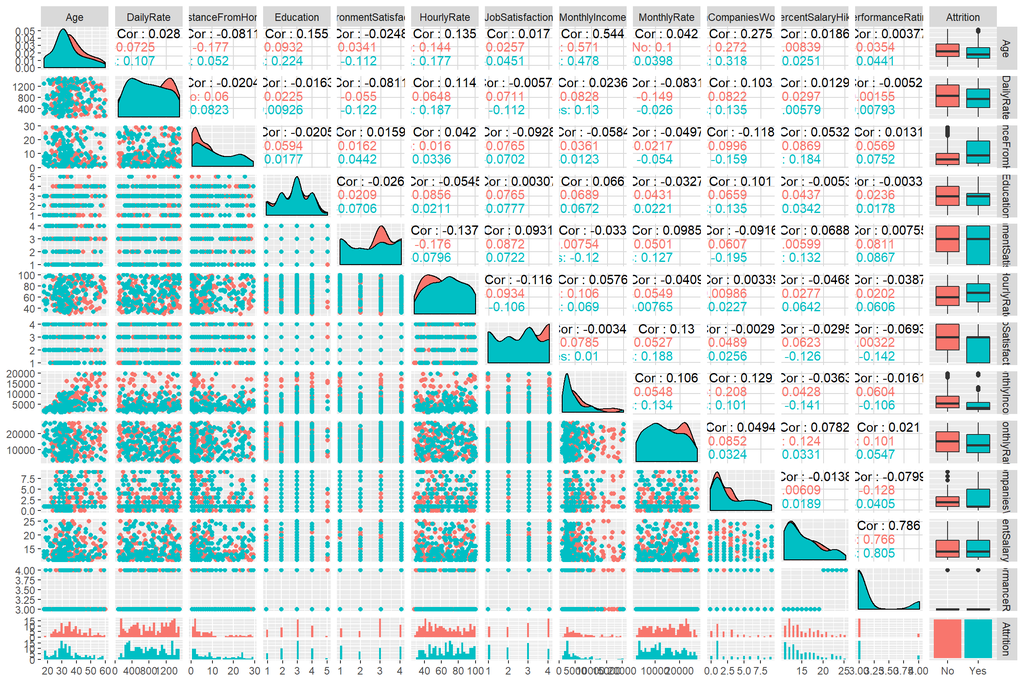

```r
#Age, DailyRate, DistanceFromHome, Education, EnvironmentSatisfaction, HourlyRate, JobSatisfaction, MonthlyIncome, MonthlyRate, NumCompaniesWorked, PercentSalaryHike, PerformanceRating,Attrition

#RelationshipSatisfaction, StandardHours, StockOptionLevel, TotalWorkingYears, TrainingTimesLastYear, WorkLifeBalance, YearsAtCompany, YearsInCurrentRole, YearsSinceLastPromotion, YearsWithCurrManager, Attrition
dfEmpDS %>%
select(Age, DailyRate, DistanceFromHome, Education, EnvironmentSatisfaction, HourlyRate, JobSatisfaction, MonthlyIncome, MonthlyRate, NumCompaniesWorked, PercentSalaryHike, PerformanceRating,Attrition) %>%
ggpairs(aes(color = Attrition)) %>% print(progress=F)
```

Here, we continue with pair plots using the remaining numerical variables. Notice that there appears to be a relationship between work life balance and attrition as well as years in current role and attrition.

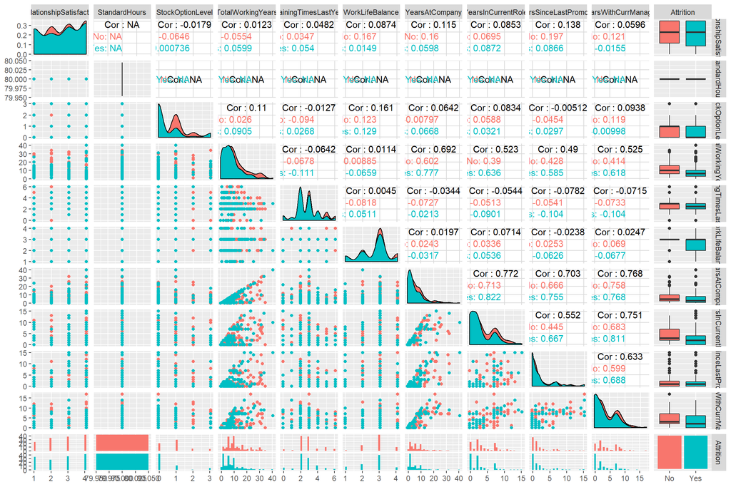

```r
#RelationshipSatisfaction, StandardHours, StockOptionLevel, TotalWorkingYears, TrainingTimesLastYear, WorkLifeBalance, YearsAtCompany, YearsInCurrentRole, YearsSinceLastPromotion, YearsWithCurrManager, Attrition
dfEmpDS %>%
select(RelationshipSatisfaction, StandardHours, StockOptionLevel, TotalWorkingYears, TrainingTimesLastYear, WorkLifeBalance, YearsAtCompany, YearsInCurrentRole, YearsSinceLastPromotion, YearsWithCurrManager, Attrition) %>%
ggpairs(aes(color = Attrition)) %>% print(progress=F)
```

Next, I create a dataframe that scales all the numerical variables.

```r
dfEmpDSnum = dfEmpDS %>%
select(Age, DailyRate, DistanceFromHome, Education, EnvironmentSatisfaction, HourlyRate, JobSatisfaction, MonthlyIncome, MonthlyRate, NumCompaniesWorked, PercentSalaryHike, PerformanceRating,RelationshipSatisfaction, StandardHours, StockOptionLevel, TotalWorkingYears, TrainingTimesLastYear, WorkLifeBalance, YearsAtCompany, YearsInCurrentRole, YearsSinceLastPromotion, NumOverTime, YearsWithCurrManager, JobInvolvement)

dfEmpCorez = as.data.frame(scale(dfEmpDSnum))
dfEmpCorez$Attrition = dfEmpDS$Attrition
summary(dfEmpCorez)
```

```
##       Age            DailyRate        DistanceFromHome    Education
##  Min.   :-1.8353   Min.   :-1.71008   Min.   :-1.0200   Min.   :-1.7188
##  1st Qu.:-0.6828   1st Qu.:-0.88774   1st Qu.:-0.9030   1st Qu.:-0.7563
##  Median :-0.1590   Median :-0.02799   Median :-0.3183   Median : 0.2063
##  Mean   : 0.0000   Mean   : 0.00000   Mean   : 0.0000   Mean   : 0.0000
##  3rd Qu.: 0.5743   3rd Qu.: 0.89692   3rd Qu.: 0.7343   3rd Qu.: 1.1688
##  Max.   : 2.4601   Max.   : 1.65652   Max.   : 2.2547   Max.   : 2.1313
##
##  EnvironmentSatisfaction   HourlyRate       JobSatisfaction   MonthlyIncome
##  Min.   :-1.4393         Min.   :-1.72499   Min.   :-1.4220   Min.   :-1.0742
##  1st Qu.:-0.5536         1st Qu.:-0.84641   1st Qu.:-0.5333   1st Qu.:-0.7279
##  Median : 0.3322         Median :-0.04207   Median : 0.3555   Median :-0.3316
##  Mean   : 0.0000         Mean   : 0.00000   Mean   : 0.0000   Mean   : 0.0000
##  3rd Qu.: 1.2179         3rd Qu.: 0.84888   3rd Qu.: 1.2443   3rd Qu.: 0.3427
##  Max.   : 1.2179         Max.   : 1.73984   Max.   : 1.2443   Max.   : 3.1908
##
##   MonthlyRate       NumCompaniesWorked PercentSalaryHike PerformanceRating
##  Min.   :-1.69849   Min.   :-1.0926    Min.   :-1.1316   Min.   :-0.4368
##  1st Qu.:-0.85508   1st Qu.:-0.7097    1st Qu.:-0.8725   1st Qu.:-0.4368
##  Median :-0.02326   Median :-0.3268    Median :-0.3544   Median :-0.4368
##  Mean   : 0.00000   Mean   : 0.0000    Mean   : 0.0000   Mean   : 0.0000
##  3rd Qu.: 0.91122   3rd Qu.: 0.8219    3rd Qu.: 0.6819   3rd Qu.:-0.4368
##  Max.   : 1.84072   Max.   : 2.3535    Max.   : 2.4953   Max.   : 2.2811
##
##  RelationshipSatisfaction StandardHours StockOptionLevel  TotalWorkingYears
##  Min.   :-1.4811          Min.   : NA   Min.   :-0.7781   Min.   :-1.2848
##  1st Qu.:-0.5893          1st Qu.: NA   1st Qu.:-0.7781   1st Qu.:-0.6431
##  Median : 0.3026          Median : NA   Median :-0.7781   Median :-0.2581
##  Mean   : 0.0000          Mean   :NaN   Mean   : 0.0000   Mean   : 0.0000
##  3rd Qu.: 1.1944          3rd Qu.: NA   3rd Qu.: 0.3112   3rd Qu.: 0.3837
##  Max.   : 1.1944          Max.   : NA   Max.   : 2.4898   Max.   : 3.8490
##                           NA's   :280
##  TrainingTimesLastYear WorkLifeBalance   YearsAtCompany    YearsInCurrentRole
##  Min.   :-2.1619       Min.   :-2.3412   Min.   :-0.9699   Min.   :-1.0234
##  1st Qu.:-0.5957       1st Qu.:-1.0142   1st Qu.:-0.6540   1st Qu.:-1.0234
##  Median : 0.1874       Median : 0.3128   Median :-0.3380   Median :-0.4332
##  Mean   : 0.0000       Mean   : 0.0000   Mean   : 0.0000   Mean   : 0.0000
##  3rd Qu.: 0.1874       3rd Qu.: 0.3128   3rd Qu.: 0.4520   3rd Qu.: 1.0424
##  Max.   : 2.5367       Max.   : 1.6398   Max.   : 5.3496   Max.   : 3.4032
##
##  YearsSinceLastPromotion  NumOverTime     YearsWithCurrManager JobInvolvement
##  Min.   :-0.65622        Min.   :-0.815   Min.   :-1.0305      Min.   :-2.061
##  1st Qu.:-0.65622        1st Qu.:-0.815   1st Qu.:-1.0305      1st Qu.:-0.770
##  Median :-0.35049        Median :-0.815   Median :-0.4435      Median : 0.521
##  Mean   : 0.00000        Mean   : 0.000   Mean   : 0.0000      Mean   : 0.000
##  3rd Qu.:-0.04477        3rd Qu.: 1.223   3rd Qu.: 1.0242      3rd Qu.: 0.521
##  Max.   : 3.92965        Max.   : 1.223   Max.   : 3.9596      Max.   : 1.812
##
##  Attrition
##  No :140
##  Yes:140
##
##
##
##
##
```

Checking to see which columns have NA’s

```r
#checking to see which columns have NA's
colnames(dfEmpCorez)[colSums(is.na(dfEmpCorez))>0]
```

```
## [1] "StandardHours"
```

Since Standard Hours have Na’s, we drop it from our dataframe

```r
drops = c("StandardHours")
dfEmpCorez = dfEmpCorez[,!(names(dfEmpCorez) %in% drops)]
```

Check again to make sure there are no other values with NA’s in the resulting dataframe befor further analysis

```r
#checking to see which columns have NA's
colnames(dfEmpCorez)[colSums(is.na(dfEmpCorez))>0]
```

```
## character(0)
```

## Feature Importance

```r
library(Boruta)
```

```r
boruta_output <- Boruta(Attrition ~ ., data=na.omit(dfEmpDS), doTrace=2) #perform Boruta search
```

```r
boruta_signif <- names(boruta_output$finalDecision[boruta_output$finalDecision %in% c("Confirmed", "Tentative")])
print(boruta_signif)
```

```
##  [1] "Age"                  "JobInvolvement"       "JobLevel"
##  [4] "JobRole"              "MaritalStatus"        "MonthlyIncome"
##  [7] "OverTime"             "StockOptionLevel"     "TotalWorkingYears"
## [10] "WorkLifeBalance"      "YearsAtCompany"       "YearsWithCurrManager"
## [13] "Class"                "NumOverTime"
```

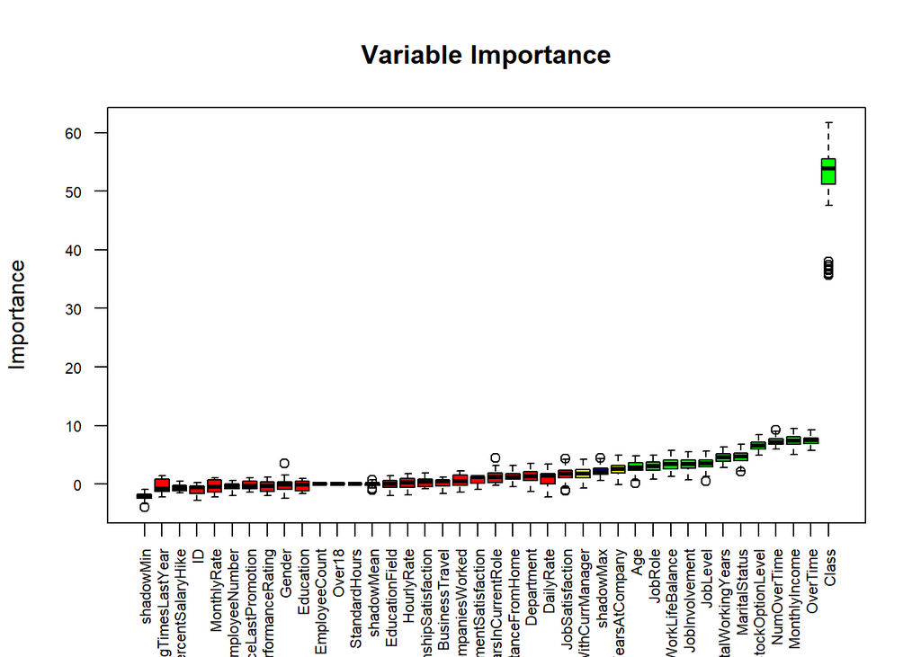

```r
plot(boruta_output, cex.axis=.7, las=2, xlab="", main="Variable Importance")
```

Checking feature importance after scaling the data.

Reveals the following most important features:

- Over Time

- Monthly Income

- Stock Option Level

- Years at Company

- Total Working Years

- Years with Current Manager

- Age

- Job Involvement

- Work Life Balance

```r
library(Boruta)

boruta_outputz <- Boruta(dfEmpCorez$Attrition ~ ., data=na.omit(dfEmpCorez), doTrace=2) #perform Boruta search
```

```r
boruta_signifz <- names(boruta_outputz$finalDecision[boruta_outputz$finalDecision %in% c("Confirmed", "Tentative")])
print(boruta_signifz)
```

```
##  [1] "Age"                     "DistanceFromHome"
##  [3] "EnvironmentSatisfaction" "JobSatisfaction"
##  [5] "MonthlyIncome"           "StockOptionLevel"
##  [7] "TotalWorkingYears"       "WorkLifeBalance"
##  [9] "YearsAtCompany"          "NumOverTime"
## [11] "YearsWithCurrManager"    "JobInvolvement"
```

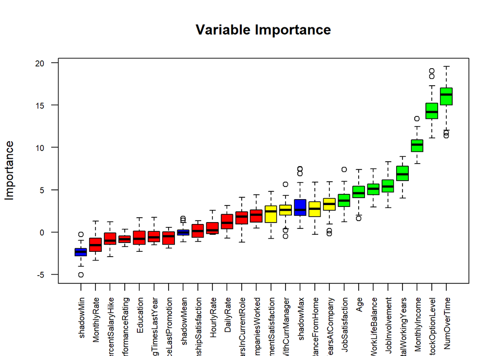

```r
plot(boruta_outputz, cex.axis=.7, las=2, xlab="", main="Variable Importance")
```

Create a dataframe that is balanced by class, scaled and has only the important features

```r
dfEmpCore = dfEmpCorez %>% select(NumOverTime, MonthlyIncome, StockOptionLevel, YearsAtCompany, TotalWorkingYears, YearsWithCurrManager, Age, JobInvolvement, WorkLifeBalance, DailyRate, YearsInCurrentRole, Attrition)
```

## Build the KNN Model

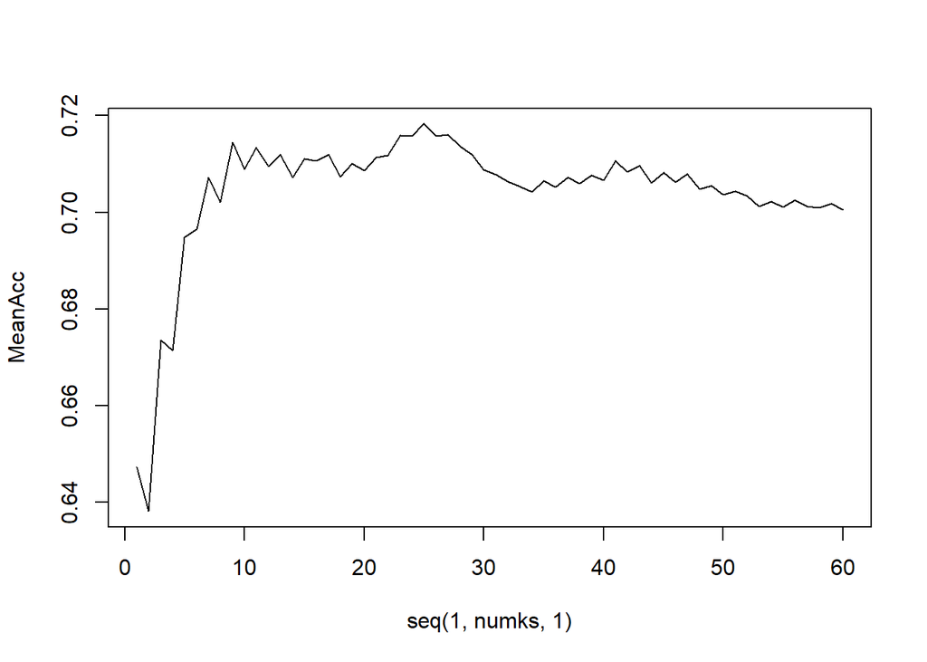

```r
library(class)
library(caret)
library(e1071)
#Use a 70 - 30 train/test split to use cross validation to
#tune the hyperparameter k


# Loop for many k and the average of many training / test partition

set.seed(12345)
iterations = 250
numks = 60
splitPerc = .70

masterAcc = matrix(nrow = iterations, ncol = numks)

for(j in 1:iterations)
{
  trainIndices = sample(1:dim(dfEmpCore)[1],round(splitPerc * dim(dfEmpCore)[1]))
  train = dfEmpCore[trainIndices,]
  test = dfEmpCore[-trainIndices,]
  for(i in 1:numks)
  {
    classifications = knn(train[,c(1:11)],test[,c(1:11)],train$Attrition, prob = TRUE, k = i)
    table(classifications,test$Attrition)
    CM = confusionMatrix(table(classifications,test$Attrition))
    masterAcc[j,i] = CM$overall[1]
  }

}

MeanAcc = colMeans(masterAcc)

plot(seq(1,numks,1),MeanAcc, type = "l")
```

```r
which.max(MeanAcc)
```

```
## [1] 25
```

```r
max(MeanAcc)
```

```
## [1] 0.7182857
```

```r
# k = 7
classifications = knn(train[,c(1:11)],test[,c(1:11)],train$Attrition, prob = TRUE, k = 35)
table(test$Attrition,classifications)
```

```
##      classifications
##       No Yes
##   No  37   5
##   Yes 21  21
```

```r
confusionMatrix(table(test$Attrition,classifications))
```

```
## Confusion Matrix and Statistics
##
##      classifications
##       No Yes
##   No  37   5
##   Yes 21  21
##
##                Accuracy : 0.6905
##                  95% CI : (0.5802, 0.7869)
##     No Information Rate : 0.6905
##     P-Value [Acc > NIR] : 0.552798
##
##                   Kappa : 0.381
##
##  Mcnemar's Test P-Value : 0.003264
##
##             Sensitivity : 0.6379
##             Specificity : 0.8077
##          Pos Pred Value : 0.8810
##          Neg Pred Value : 0.5000
##              Prevalence : 0.6905
##          Detection Rate : 0.4405
##    Detection Prevalence : 0.5000
##       Balanced Accuracy : 0.7228
##
##        'Positive' Class : No
##
```

##Attrition Classification against Competition Dataset

Now we need to perform the Attrition Classification using the data set “CaseStudy2CompSet No Attrition.csv”, which has no attrition labels. So, first we load the dataset.

```r
#load the data
dfToClassify = read.csv("C:/Users/BGaither/OneDrive - McAfee/Other/school/SMU/Courses/Spring 2020/Doing Data Science/Project2/CaseStudy2CompSet No Attrition.csv",header = TRUE)
```

Now we need to create a dataframe with the new data that scales all the necessary variables to be able to use KNN.

```r
#create the numovertime variable
dfToClassify$NumOverTime = ifelse(dfToClassify$OverTime=="Yes",1,0)

# dfToClassifynum = dfToClassify %>%
# select(Age, DailyRate, DistanceFromHome, Education, EnvironmentSatisfaction, HourlyRate, JobSatisfaction, MonthlyIncome, MonthlyRate, NumCompaniesWorked, PercentSalaryHike, PerformanceRating,RelationshipSatisfaction, StandardHours, StockOptionLevel, TotalWorkingYears, TrainingTimesLastYear, WorkLifeBalance, YearsAtCompany, YearsInCurrentRole, YearsSinceLastPromotion, NumOverTime, YearsWithCurrManager, JobInvolvement)

dfToClassifynum = dfToClassify %>%
select(NumOverTime, MonthlyIncome, StockOptionLevel, YearsAtCompany, TotalWorkingYears, YearsWithCurrManager, Age, JobInvolvement, WorkLifeBalance, DailyRate, YearsInCurrentRole)

dfToClassifynum_z = as.data.frame(scale(dfToClassifynum))
#dfToClassifynum_z$Attrition = dfEmpDS$Attrition
summary(dfToClassifynum_z)
```

```
##   NumOverTime      MonthlyIncome     StockOptionLevel  YearsAtCompany
##  Min.   :-0.6432   Min.   :-1.1081   Min.   :-0.9032   Min.   :-1.0892
##  1st Qu.:-0.6432   1st Qu.:-0.7681   1st Qu.:-0.9032   1st Qu.:-0.6551
##  Median :-0.6432   Median :-0.3576   Median : 0.2498   Median :-0.3657
##  Mean   : 0.0000   Mean   : 0.0000   Mean   : 0.0000   Mean   : 0.0000
##  3rd Qu.: 1.5495   3rd Qu.: 0.4995   3rd Qu.: 0.2498   3rd Qu.: 0.3579
##  Max.   : 1.5495   Max.   : 2.4289   Max.   : 2.5558   Max.   : 4.2653
##  TotalWorkingYears YearsWithCurrManager      Age          JobInvolvement
##  Min.   :-1.4503   Min.   :-1.1237      Min.   :-1.9620   Min.   :-2.3310
##  1st Qu.:-0.7506   1st Qu.:-0.6106      1st Qu.:-0.7134   1st Qu.:-0.9939
##  Median :-0.2841   Median :-0.3540      Median :-0.1932   Median : 0.3432
##  Mean   : 0.0000   Mean   : 0.0000      Mean   : 0.0000   Mean   : 0.0000
##  3rd Qu.: 0.6488   3rd Qu.: 0.6722      3rd Qu.: 0.6392   3rd Qu.: 0.3432
##  Max.   : 2.9810   Max.   : 3.2377      Max.   : 2.3040   Max.   : 1.6803
##  WorkLifeBalance     DailyRate        YearsInCurrentRole
##  Min.   :-2.5279   Min.   :-1.68947   Min.   :-1.2295
##  1st Qu.:-1.0806   1st Qu.:-0.83332   1st Qu.:-0.6616
##  Median : 0.3666   Median :-0.02418   Median :-0.3777
##  Mean   : 0.0000   Mean   : 0.00000   Mean   : 0.0000
##  3rd Qu.: 0.3666   3rd Qu.: 0.82207   3rd Qu.: 0.7582
##  Max.   : 1.8139   Max.   : 1.74503   Max.   : 3.8816
```

Classify using the scaled data and add a column called Attrition to hold the classifications.

```r
dfToClassifynum_z$Attrition = knn(train[,c(1:11)],dfToClassifynum_z[,c(1:11)],train$Attrition, prob = TRUE, k = 35)
```

Now, we’ll add the classified column Attrition to the original dataframe with the original data so that we can submit the file for grading.

```r
dfToClassify$Attrition = dfToClassifynum_z$Attrition
```

Now that we have the file with the Attrition column, output the dataframe with classifications to a csv file for grading.

```r
write.csv(dfToClassify,"C:/Users/BGaither/OneDrive - McAfee/Other/school/SMU/Courses/Spring 2020/Doing Data Science/Project2/Case2Predictions_Gaither_Attrition.csv", row.names = FALSE)
```

# Attrition by Job Role

Let’s analyze job role versus attrition to see if we can identify any patterns. By simply looking a the count of attrition by job role, it looks like Sales Eecutive, Research Scientist and Labratory Technician roles have highest attrition by count. However, this is misleading as there are a lot more people in those roles. Let’s look at attrition as a percent of people to give a more accurate picture of what’s going on.

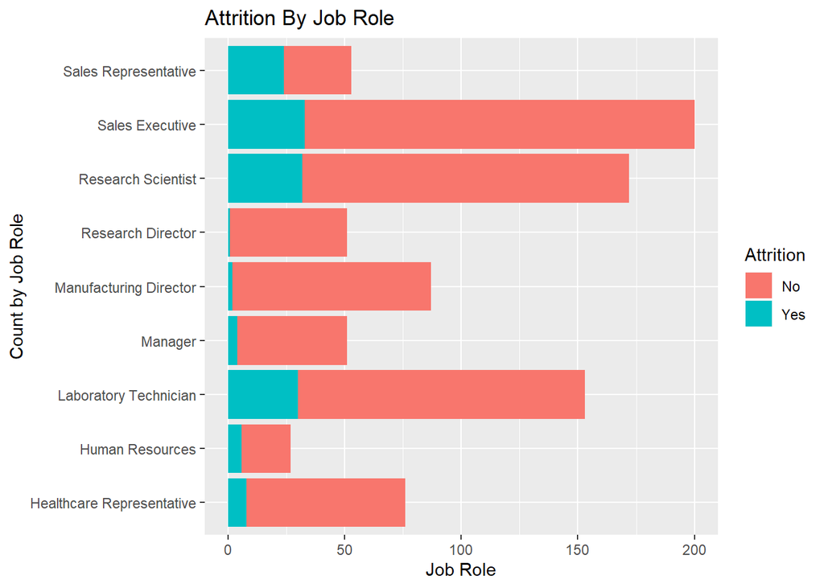

```r
dfEmployees %>% ggplot(mapping=aes(x=JobRole, fill=Attrition)) + geom_bar() + coord_flip() + ggtitle("Attrition By Job Role") + xlab("Count by Job Role") + ylab("Job Role")
```

Here, we do the math to calculate the percent attrition for each role

```r
library(dplyr)
dfHolder = dfEmployees %>% filter(Attrition == "No") %>% group_by(JobRole) %>% count(Attrition)
dfHolder_Yes = dfEmployees %>% filter(Attrition == "Yes") %>% group_by(JobRole) %>% count(Attrition)
dfHolder$n_Yes = dfHolder_Yes$n
dfHolder$TotalEmps = rowSums(cbind(dfHolder$n_Yes, dfHolder$n))
dfHolder$PercentYes = dfHolder$n_Yes / dfHolder$TotalEmps
dfHolder$PercentNo = dfHolder$n / dfHolder$TotalEmps
```

Now, when we plot attrition as a percent by each role, we get a different picture. We see that the top roles for attrition are: + Sales Representative + Human Resources + Laboratory Techician

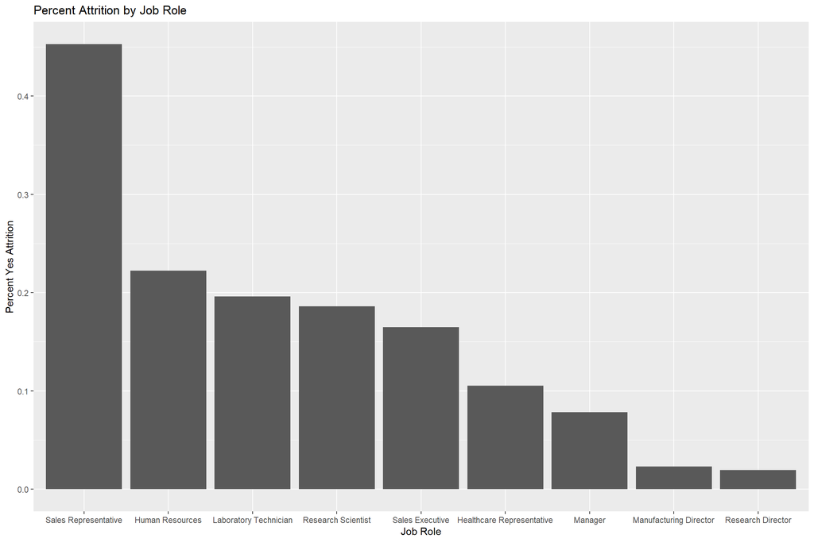

```r
dfHolder %>% ggplot(mapping=aes(x=reorder(JobRole, -PercentYes), y=PercentYes)) + geom_col() + ggtitle("Percent Attrition by Job Role") + ylab("Percent Yes Attrition") + xlab("Job Role")
```

## Salary Analysis

Let’s start looking at salary data with the ultimate goal of being able to predict monthly salaries

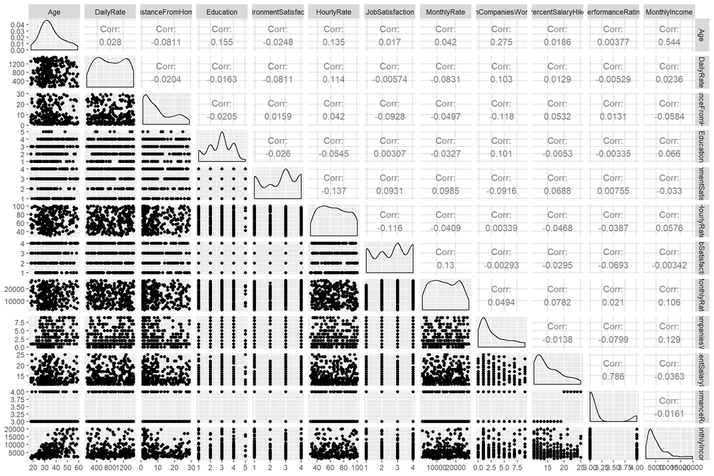

```r
dfEmpDS %>%
select(Age, DailyRate, DistanceFromHome, Education, EnvironmentSatisfaction, HourlyRate, JobSatisfaction, MonthlyRate, NumCompaniesWorked, PercentSalaryHike, PerformanceRating, MonthlyIncome) %>%
ggpairs() %>% print(progress=F)
```

Continuing our pair plot analysis on remaining numerical data

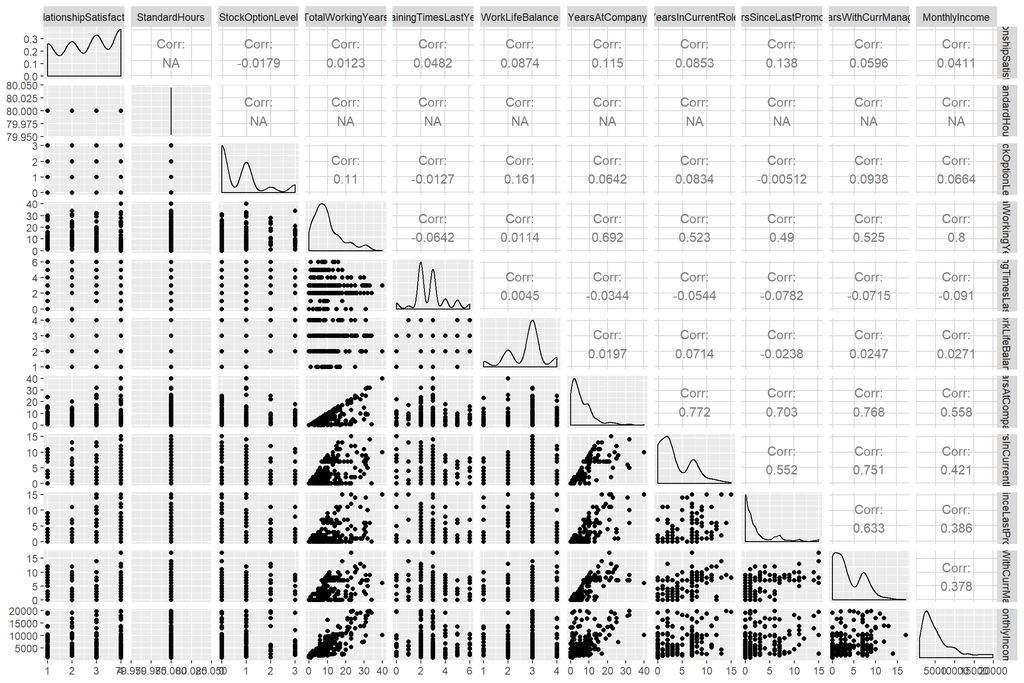

```r
#RelationshipSatisfaction, StandardHours, StockOptionLevel, TotalWorkingYears, TrainingTimesLastYear, WorkLifeBalance, YearsAtCompany, YearsInCurrentRole, YearsSinceLastPromotion, YearsWithCurrManager, Attrition
dfEmpDS %>%
select(RelationshipSatisfaction, StandardHours, StockOptionLevel, TotalWorkingYears, TrainingTimesLastYear, WorkLifeBalance, YearsAtCompany, YearsInCurrentRole, YearsSinceLastPromotion, YearsWithCurrManager, MonthlyIncome) %>%
ggpairs() %>% print(progress=F)
```

After analyzing the above pair plots, I’ve reduced the variables down to the highest correlated values against Monthly income

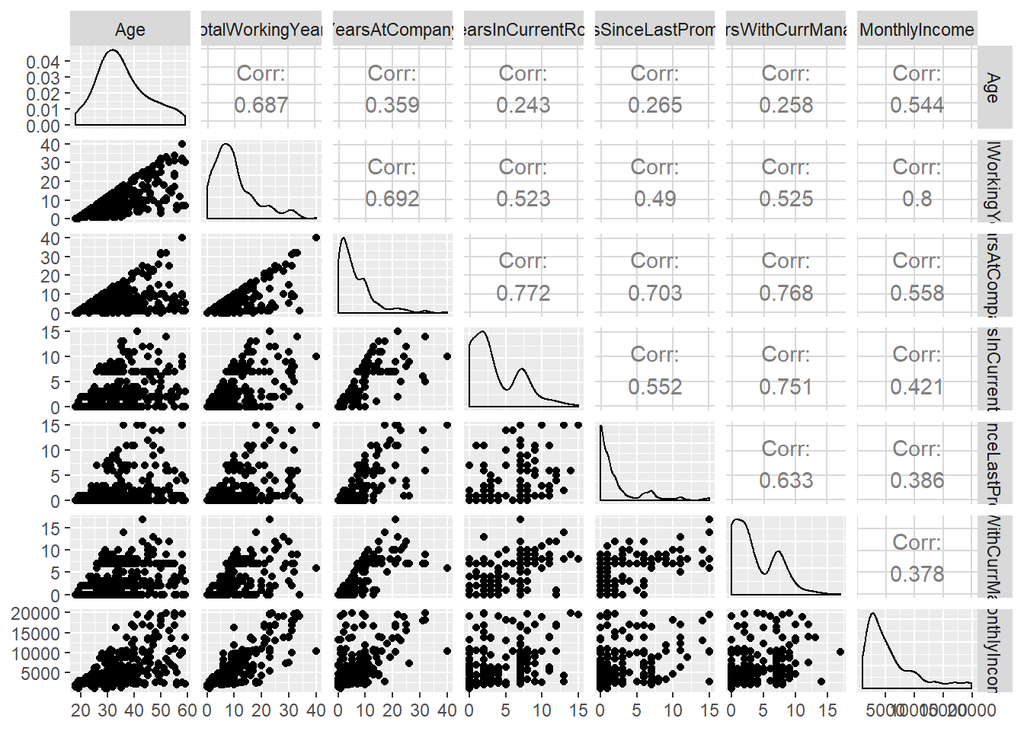

```r
dfEmpDS %>%
select(Age, TotalWorkingYears, YearsAtCompany, YearsInCurrentRole, YearsSinceLastPromotion, YearsWithCurrManager, MonthlyIncome) %>%
ggpairs() %>% print(progress=F)
```

Let’s log transform MonthlyIncome

```r
dfEmpDS_Log = dfEmpDS
dfEmpDS_Log$lMonthlyIncome = log(dfEmpDS_Log$MonthlyIncome)
dfEmpDS_Log$lYearsAtCompany = log(dfEmpDS_Log$YearsAtCompany)
dfEmpDS_Log$lYearsInCurrentRole = log(dfEmpDS_Log$YearsInCurrentRole)
```

Now, let’s check a further reduced set of variable correlations against a log transformed Monthly Income

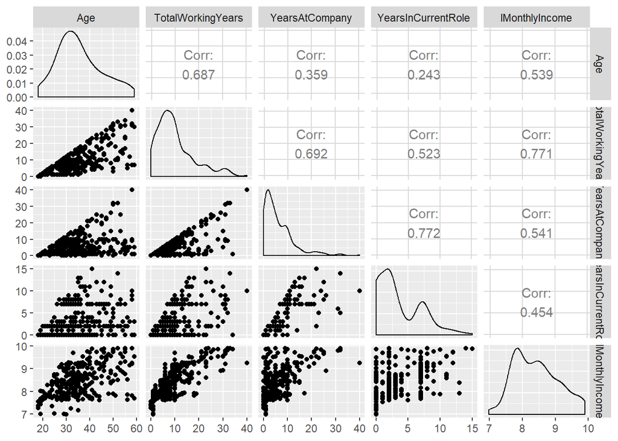

```r
dfEmpDS_Log %>%
select(Age, TotalWorkingYears, YearsAtCompany, YearsInCurrentRole, lMonthlyIncome) %>%
ggpairs() %>% print(progress=F)
```

Highest correlated features with Monthly Income: TotalWorkingYears

response variable: MonthlyIncome Notice there appears to be a slight curve in the plot between MonthlyIncome and TotalWorkingYears so we’ll add a quadratic term to address that Let’s build the regression model

```r
SalaryModel1 = lm(lMonthlyIncome~ TotalWorkingYears + I(TotalWorkingYears^2) + JobRole, data=dfEmpDS_Log)
```

Let’s examine the results. The coefficients all appear to be significant with the exception of a couple of levels of the JobRole

```r
summary(SalaryModel1)
```

```
##
## Call:
## lm(formula = lMonthlyIncome ~ TotalWorkingYears + I(TotalWorkingYears^2) +
##     JobRole, data = dfEmpDS_Log)
##
## Residuals:
##      Min       1Q   Median       3Q      Max
## -0.71766 -0.19126 -0.00113  0.22440  0.60627
##
## Coefficients:
##                                 Estimate Std. Error t value Pr(>|t|)
## (Intercept)                    8.2913866  0.0854775  97.001  < 2e-16 ***
## TotalWorkingYears              0.0554860  0.0077447   7.164 7.50e-12 ***
## I(TotalWorkingYears^2)        -0.0007615  0.0002333  -3.264  0.00124 **
## JobRoleHuman Resources        -0.7335502  0.1172132  -6.258 1.53e-09 ***
## JobRoleLaboratory Technician  -0.6235727  0.0756615  -8.242 7.53e-15 ***
## JobRoleManager                 0.5507123  0.1049889   5.245 3.16e-07 ***
## JobRoleManufacturing Director -0.0042211  0.0864148  -0.049  0.96108
## JobRoleResearch Director       0.6208990  0.1101855   5.635 4.41e-08 ***
## JobRoleResearch Scientist     -0.6292039  0.0750917  -8.379 3.00e-15 ***
## JobRoleSales Executive         0.0354334  0.0710329   0.499  0.61831
## JobRoleSales Representative   -0.6967810  0.0905509  -7.695 2.69e-13 ***
## ---
## Signif. codes:  0 '***' 0.001 '**' 0.01 '*' 0.05 '.' 0.1 ' ' 1
##
## Residual standard error: 0.2822 on 269 degrees of freedom
## Multiple R-squared:  0.8315, Adjusted R-squared:  0.8252
## F-statistic: 132.7 on 10 and 269 DF,  p-value: < 2.2e-16
```

Let’s check the residual Sum of Squares, Mean Squared Error and Root Mean Squared Error

```r
#residual sum of squares
RSS = c(crossprod(SalaryModel1$residuals))
RSS
```

```
## [1] 21.42874
```

```r
#Mean Squared Error
MSE = RSS / length(SalaryModel1$residuals)
MSE
```

```
## [1] 0.07653123
```

```r
#Root MSE
RMSE = sqrt(MSE)
RMSE
```

```
## [1] 0.2766428
```

Let’s back transform RMSE since it’s based on the log of Monthly Income

```r
exp(RMSE)
```

```
## [1] 1.318695
```

Let’s look at how well the model predicts salary compared to the actual salary data we have

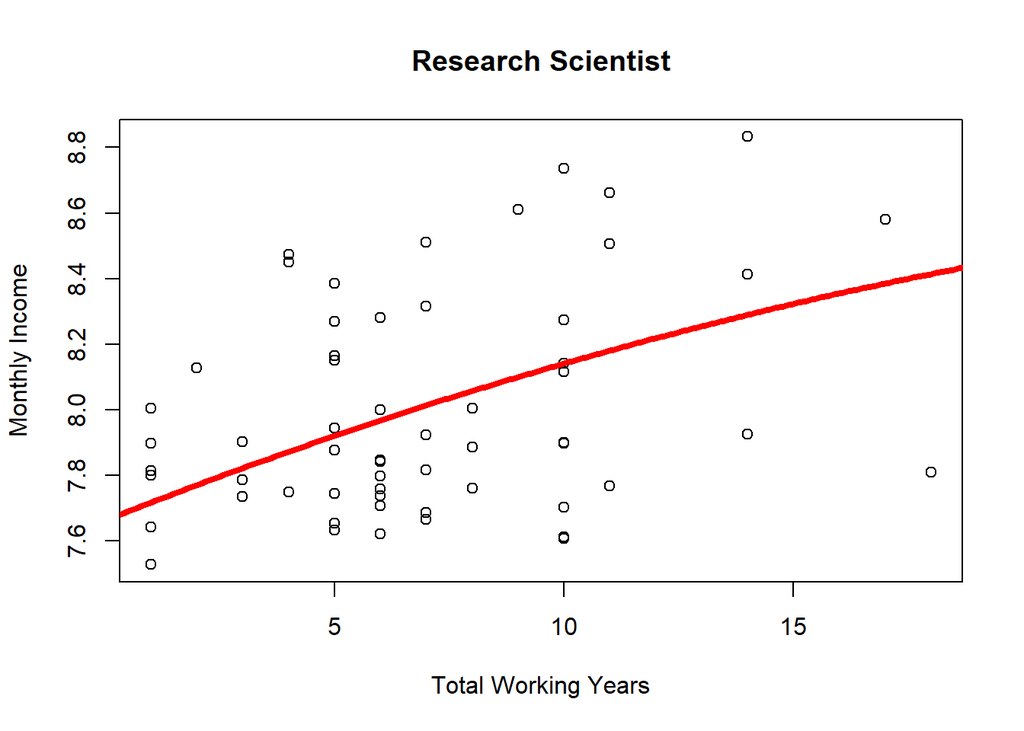

```r
#here we can plug in one of the job roles that we want to evaluate
testRole = "Research Scientist"
dfPlotSpecific = dfEmpDS_Log %>% filter(dfEmpDS_Log$JobRole == testRole)
plot(dfPlotSpecific$TotalWorkingYears,dfPlotSpecific$lMonthlyIncome, xlab="Total Working Years",ylab="Monthly Income", main= testRole)
new<-data.frame(TotalWorkingYears=seq(0,40,.1), JobRole = testRole)
lines(seq(0,40,.1),predict(SalaryModel1,newdata=new),col="red",lwd=4)
```

Plotting residuals on TotalWorkingYears we see nice constant variance

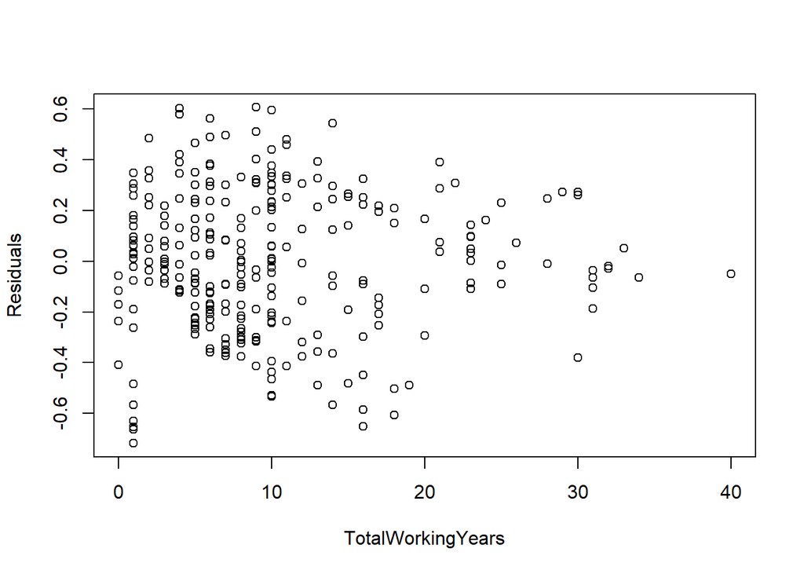

```r
plot(dfEmpDS_Log$TotalWorkingYears ,SalaryModel1$residuals,xlab="TotalWorkingYears",ylab="Residuals")
```

The residual plot indicates no pattern which is what we want

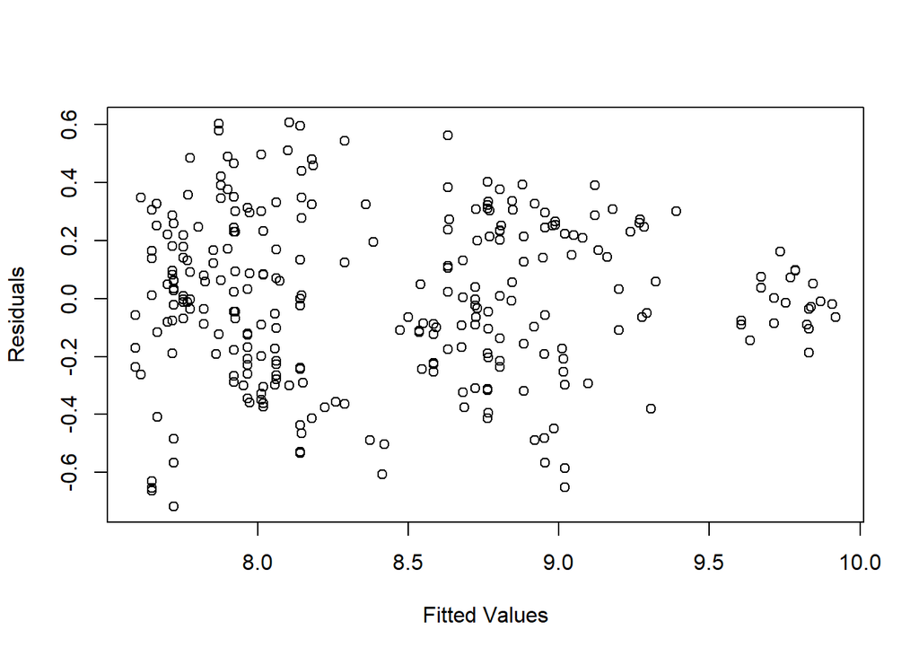

```r
plot(SalaryModel1$fitted.values,SalaryModel1$residuals,xlab="Fitted Values",ylab="Residuals")
```

Now we need to perform the monthly income prediction using the data set “CaseStudy2CompSet No Salary.csv”, which has no Salary data. First we load the data.

```r
#load the data
dfToPredict = read.csv("C:/Users/BGaither/OneDrive - McAfee/Other/school/SMU/Courses/Spring 2020/Doing Data Science/Project2/CaseStudy2CompSet No Salary.csv",header = TRUE)
```

Use the model to predict the monthly salaries and add it to the dataframe

```r
dfToPredict$MonthlyIncome = exp(predict(SalaryModel1,newdata=data.frame(TotalWorkingYears = dfToPredict$TotalWorkingYears, JobRole = dfToPredict$JobRole)))
```

Let’s check our work with plots

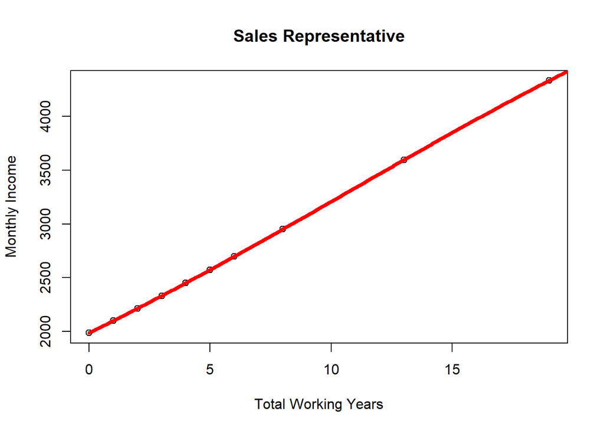

```r
#here we can plug in one of the job roles that we want to evaluate
testRole = "Sales Representative"
dfPlotSpecific = dfToPredict %>% filter(dfToPredict$JobRole == testRole)
plot(dfPlotSpecific$TotalWorkingYears,dfPlotSpecific$MonthlyIncome, xlab="Total Working Years",ylab="Monthly Income", main= testRole)
new<-data.frame(TotalWorkingYears=seq(0,40,.1), JobRole = testRole)
lines(seq(0,40,.1),exp(predict(SalaryModel1,newdata=new)),col="red",lwd=4)
```

Now that we have the dataframe with the predicted MonthlyIncome column, output the dataframe with classifications to a csv file for grading.

```r
write.csv(dfToPredict,"C:/Users/BGaither/OneDrive - McAfee/Other/school/SMU/Courses/Spring 2020/Doing Data Science/Project2/Case2Predictions_Gaither_Salary.csv", row.names = FALSE)
```